# Examining the Relationship Between Trip Duration and Other Factors

## by Sarah Irungu

## Investigation Overview

In this investigation, I wanted to gain insights into the usage patterns and durations. I analyzed the duration variable and also its relationship with other variables e.g. user type and time of day.

## Dataset Overview

The data included in the bike share trip dataset was collected during the month of February 2019. It has more that 170k rows and 16 variables. It includes duration of a trip, start and end time of trips, among other variables. Some rows and columns were removed due to missing data and outliers.

## Distribution of a Trip Duration

The duration of bike trips has a great range of values from about **50** seconds to **80k** seconds. After plotting using log scale, the distribution has a single peak, giving it a unimodal shape.

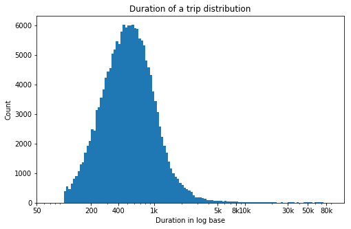

## Distribution of Birth Group Year

Birth group year has year of birth grouped into groups of 10 years. The distribution plot shows that many bike users have the year of birth between 1980 and 1989 followed by those of 1990 and 1999.

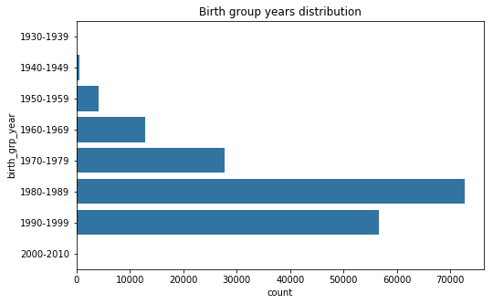

## Day of Week vs Hour of Day

The peak bike usage hours on weekdays fall between 5 a.m and 10 a.m and 3 p.m to 8 p.m, whereas on weekends they occur between 10 a.m and 3 p.m.

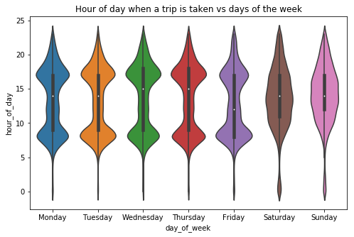

## Hour of Day vs Duration Seconds

Between midnight and 5 a.m, we observe the highest average duration time of trips.

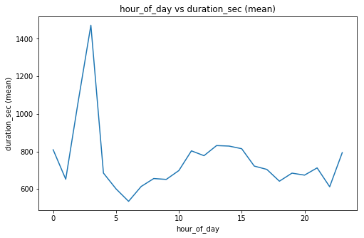

## Day of Week vs Duration Seconds vs User Type

Compared to customers, subscribers tend to have a shorter average duration time for their bike usage. This suggests that there may be differences in the patterns of purposes for which subscribers and customers use the bikes.

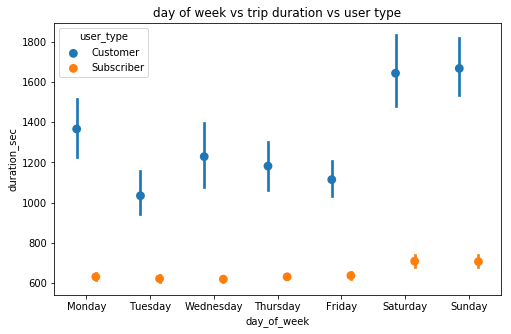